# Getting (Slightly) More Comfortable With Public Speaking

Ryan Estrellado

2/9/2018

This handout is about reframing our worries and fears about public speaking, coming up with practical ways to reduce our worries about public speaking, and encouraging others to try public speaking more.

In [her TED talk](https://www.ted.com/talks/kelly_mcgonigal_how_to_make_stress_your_friend), Kelly McGonigal encourages the audience to view stress as our body’s mechanism for preparing for a challenge. In the context of this handout, this is useful for two reasons: First, it normalizes the experience of stress. Though different people feel different levels of stress around public speaking, stress is very much a natural thing and should be expected. Second, when we feel stress around public speaking and we think “this feeling is useful for preparing me to rise to the challenge of doing this talk”, we’re more likely to welcome a reasonable amount of stress. We can even benefit from the increased focus and concentration that stress tends to bring.

# Fear Reduction, Not Fear Elimination

I generally find that it’s not useful to take on the goal of having zero fear before a talk. That’s an unattainable goal for me. I have observed over fifteen years of public speaking that I’ve been *more* scared before some talks than others. So a more useful question is, what are the behaviors you can demonstrate in the days leading up to your talk that *reduce* fear. Here are the behaviors that I found reduce my fear and anxiety:

- Read through my presentation slides multiple times
- Write out concepts I find difficult to talk about clearly
- Try and explain a concept in my talk using plain language to someone I know, like my kids or my friends
- Pick a concept or a slide and explain it out loud. I like to do this in the car on the way to work or on the way home

I think of these little routines as coins I can use to buy “anxiety reduction.” While I can never completely eliminate my anxiety ahead of a talk, I can pay it down just a little bit every time I demonstrate one of the behaviors above. It’s also worth noting that I find each of these activities uncomfortable and I have a tendency to avoid them, but I almost always find them rewarding.

# Find the Right Challenge for You

I find it useful to try and find projects that give me just the right balance of skill and challenge. In Mihaly Csikszentmihalyi’s book [Flow](https://en.wikipedia.org/wiki/Mihaly_Csikszentmihalyi), he demonstrates this idea through a mental model that compares the difficulty of a task against a person’s skill level.

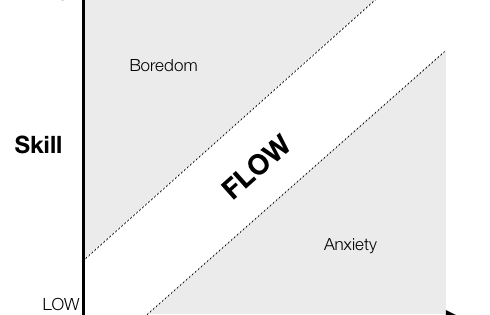

Skill v Difficulty

[Image from peakexperiences.co](https://peakexperiences.co/flow-state-speed-learning-how-to-drift/)

So if you are feeling overwhelmed by the idea of public speaking, it may be helpful to ask yourself some questions to help uncover a good next step for you. Here are some examples, but do some reflecting and come up with ones that are useful for you.

- How well does the topic of your talk match your skill to the level of difficulty? Does it put you outside of your comfort zone, but only moderately?
- Does the number of people you speak to increase anxiety as the number goes up and down? How does the size of your audience need to change in order for you to be outside your comfort zone, but only moderately?

# Tips for Coaching Folks Who Are Nervous About Public Speaking

When coaching someone who is nervous about public speaking, you can help by finding a project for them that gives them just the right balance of skill and challenge. For example, if a group member is nervous about volunteering to give a talk, do some active listening to uncover what they’re nervous about. Then you can find a project that keeps them mostly in their comfort zone, but also pushes them just a little out of it. Here are some concrete examples:

- Imagine a person is nervous about talking in front of a lot of people, but has demonstrated ease and confidence when talking with two people. Find a speaking opportunity that is in front of a group of 5-10 people
- Imagine a person is nervous talking about an area that they don’t have a lot of experience in. Find a speaking opportunity that involves talking about content that they do have experience in, but gently encourage them to add a component that requires them to learn something new. For example, if a presenter has been using base R for years, find an opportunity for them to give a talk that is 85 percent about base R and 15 percent on a subject they’d have to learn, like using the `tidyverse`.